# Signal Detection Theory (SDT)

Generalized Linear Models

# Theory

Within the SDT framework for a yes-no task, the *criterion* or response bias is the tendency to say yes or no (Stanislaw & Todorov, 1999). The criterion is formalized in Equation 1.

$$c = -\frac{\Phi(H) + \Phi(FA)}{2}
\tag{1}$$

- When $FA > MISS$ there is a tendency to say *yes* and the criterion is negative (i.e., *liberal*).
- When $FA < MISS$ there is a tendency to say *no* and the criterion is positive (i.e., *conservative*)

# SDT as GLM

The SDT parameters can be estimated using a Generalized Linear Model (see DeCarlo, 1998). In particular, using a Binomial model with a probit link function. The response variable is the *yes-no* response from participants and the predictor is the binary variable indicating if the signal was present or absent. The model intercept is the criterion as defined in Equation 1 only when the predictor (signal present vs absent) is coded using -0.5 and 0.5 (and not the default dummy coding). The model slope is the $d'$.

# Example

We can simulate a detection experiment and trying to recover the true parameters with the standard calculation and the GLM approach.

```r
set.seed(2025)
n <- 1e3 # number of trials, a lot for precision
is_signal <- rep(0:1, each = n) # signal present vs absent
d <- 1 # dprime, distance between signal and noise
c <- 0 # criterion, unbiased

# internal evidence (latent) signal + noise
signal <- ifelse(is_signal == 0, rnorm(n, 0, 1), rnorm(n, d, 1))

# decision based on evidence and criterion
say_signal <- ifelse(signal > (d/2 + c), 1, 0)
```

This is the true signal and noise distribution is depicted in Figure 1.

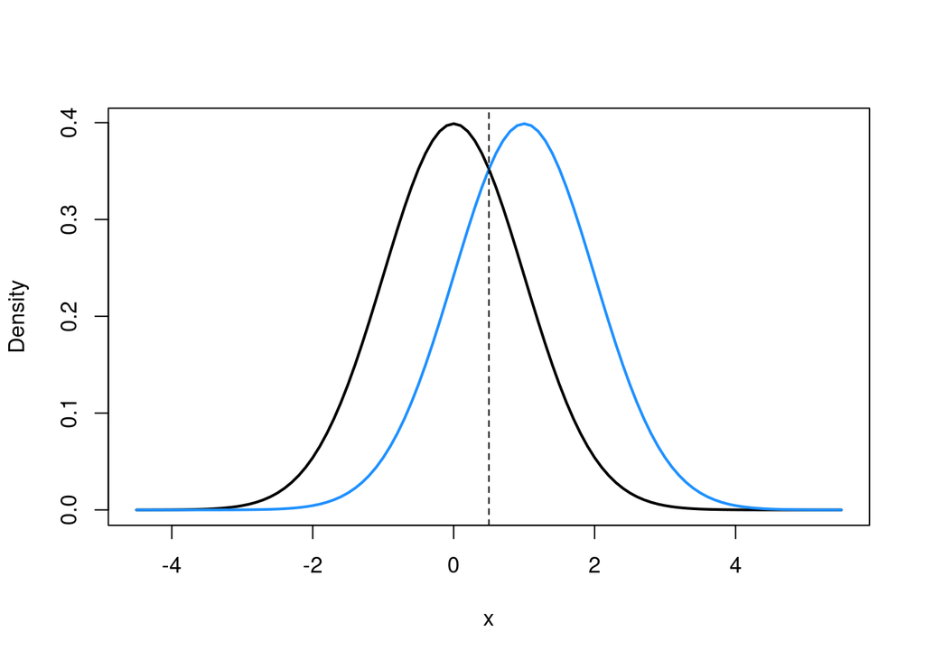

Figure 1: Example of the SDT model with $d = 1$ and $c = 0$

Then we can compute the SDT measures using the `psycho::dprime()` function.

```r
hit   <- sum(is_signal == 1 & say_signal == 1)
fa    <- sum(is_signal == 0 & say_signal == 1)
miss  <- sum(is_signal == 1 & say_signal == 0)
cr    <- sum(is_signal == 0 & say_signal == 0)

psycho::dprime(hit, fa, miss, cr)
```

```
$dprime
[1] 0.9656472

$beta
[1] 1.028943

$aprime
[1] 0.7706689

$bppd
[1] 0.01807829

$c
[1] 0.02954709
```

Let’s simulate a biased criterion. A positive criterion should be a tendency to say NO, thus higher number of misses and lower false alarm.

```r
set.seed(2025)
n <- 1e3 # number of trials, a lot for precision
is_signal <- rep(0:1, each = n) # signal present vs absent
d <- 1 # dprime, distance between signal and noise
c <- 0.5 # criterion, unbiased

# internal evidence (latent) signal + noise
signal <- ifelse(is_signal == 0, rnorm(n, 0, 1), rnorm(n, d, 1))

# decision based on evidence and criterion
say_signal <- ifelse(signal > (d/2 + c), 1, 0)

hit   <- sum(is_signal == 1 & say_signal == 1)
fa    <- sum(is_signal == 0 & say_signal == 1)
miss  <- sum(is_signal == 1 & say_signal == 0)
cr    <- sum(is_signal == 0 & say_signal == 0)

psycho::dprime(hit, fa, miss, cr)
```

```
$dprime
[1] 0.9888458

$beta
[1] 1.692251

$aprime
[1] 0.7698217

$bppd
[1] 0.3192191

$c
[1] 0.5319936
```

```r
c(
    hit = hit,
    miss = miss,
    fa = fa,
    cr = cr
)
```

```
 hit miss   fa   cr
 485  515  152  848
```

Now let’s simulate a negative criterion thus the tendency to say YES where false alarm are higher than misses.

```r
set.seed(2025)
n <- 1e3 # number of trials, a lot for precision
is_signal <- rep(0:1, each = n) # signal present vs absent
d <- 1 # dprime, distance between signal and noise
c <- -0.5 # criterion, unbiased

# internal evidence (latent) signal + noise
signal <- ifelse(is_signal == 0, rnorm(n, 0, 1), rnorm(n, d, 1))

# decision based on evidence and criterion
say_signal <- ifelse(signal > (d/2 + c), 1, 0)

hit   <- sum(is_signal == 1 & say_signal == 1)
fa    <- sum(is_signal == 0 & say_signal == 1)
miss  <- sum(is_signal == 1 & say_signal == 0)
cr    <- sum(is_signal == 0 & say_signal == 0)

sdt <- psycho::dprime(hit, fa, miss, cr)
sdt
```

```
$dprime
[1] 0.909072

$beta
[1] 0.6630337

$aprime
[1] 0.7566755

$bppd
[1] -0.2535205

$c
[1] -0.4520319
```

```r
c(
    hit = hit,
    miss = miss,
    fa = fa,
    cr = cr
)
```

```
 hit miss   fa   cr
 818  182  499  501
```

Finally let’s use a GLM to estimate SDT parameters from the last simulation:

```r
dat <- data.frame(
    say_signal,
    is_signal
)

dat$is_signal <- factor(dat$is_signal)

fit <- glm(say_signal ~ is_signal,
           data = dat,
           contrasts = list(is_signal = contr.sum(2)/2),
           family = binomial(link = "probit"))

summary(fit)
```

```
Call:
glm(formula = say_signal ~ is_signal, family = binomial(link = "probit"),
    data = dat, contrasts = list(is_signal = contr.sum(2)/2))

Coefficients:
            Estimate Std. Error z value Pr(>|z|)
(Intercept)  0.45263    0.03043   14.88   <2e-16 ***
is_signal1  -0.91028    0.06085  -14.96   <2e-16 ***
---
Signif. codes:  0 '***' 0.001 '**' 0.01 '*' 0.05 '.' 0.1 ' ' 1

(Dispersion parameter for binomial family taken to be 1)

    Null deviance: 2568.1  on 1999  degrees of freedom
Residual deviance: 2335.1  on 1998  degrees of freedom
AIC: 2339.1

Number of Fisher Scoring iterations: 3
```

The `(Intercept)` is the criterion and `is_signal1` the $d'$. The values are pretty similar to the `psycho::dprime()` function but the sign is reverted:

```r
# psycho::dprime()
c(
    c = sdt$c,
    dprime = sdt$dprime
)
```

```
         c     dprime
-0.4520319  0.9090720
```

```r
# glm
coef(fit)
```

```
(Intercept)  is_signal1
  0.4526314  -0.9102761
```

Firstly we need to change the sign of the contrasts:

```r
fit <- glm(say_signal ~ is_signal,
           data = dat,
           contrasts = list(is_signal = -contr.sum(2)/2),
           family = binomial(link = "probit"))

summary(fit)
```

```
Call:
glm(formula = say_signal ~ is_signal, family = binomial(link = "probit"),
    data = dat, contrasts = list(is_signal = -contr.sum(2)/2))

Coefficients:
            Estimate Std. Error z value Pr(>|z|)
(Intercept)  0.45263    0.03043   14.88   <2e-16 ***
is_signal1   0.91028    0.06085   14.96   <2e-16 ***
---
Signif. codes:  0 '***' 0.001 '**' 0.01 '*' 0.05 '.' 0.1 ' ' 1

(Dispersion parameter for binomial family taken to be 1)

    Null deviance: 2568.1  on 1999  degrees of freedom
Residual deviance: 2335.1  on 1998  degrees of freedom
AIC: 2339.1

Number of Fisher Scoring iterations: 3
```

But this affect only the $d'$ that now is correct in terms of sign. To recover the parameters of the conventional way of expressing the criterion we can:

- simply change the sign of the intercept (and the confidence interval)
- change the response variable to 1 = not seen and 0 = seen

```r
summ <- broom::tidy(fit, conf.int = TRUE)
summ[1, "estimate"] <- summ[1, "estimate"] * -1
summ[1, "statistic"] <- summ[1, "statistic"] * -1
ci <- c(summ$conf.low[1], summ$conf.high[1])
ci <- -1 * rev(ci)
summ[1, "conf.low"] <- ci[1]
summ[1, "conf.high"] <- ci[2]
summ
```

```
# A tibble: 2 × 7
  term        estimate std.error statistic  p.value conf.low conf.high
  <chr>          <dbl>     <dbl>     <dbl>    <dbl>    <dbl>     <dbl>
1 (Intercept)   -0.453    0.0304     -14.9 4.68e-50   -0.512    -0.393
2 is_signal1     0.910    0.0609      15.0 1.36e-50    0.791     1.03
```

```r
dat$say_signal_rev <- ifelse(dat$say_signal == 1, 0, 1)

fit_rev <- glm(say_signal_rev ~ is_signal,
               data = dat,
               contrasts = list(is_signal = contr.sum(2)/2),
               family = binomial(link = "probit"))

broom::tidy(fit_rev, conf.int = TRUE)
```

```
# A tibble: 2 × 7
  term        estimate std.error statistic  p.value conf.low conf.high
  <chr>          <dbl>     <dbl>     <dbl>    <dbl>    <dbl>     <dbl>
1 (Intercept)   -0.453    0.0304     -14.9 4.68e-50   -0.512    -0.393
2 is_signal1     0.910    0.0609      15.0 1.36e-50    0.791     1.03
```

# Predictors on SDT parameters

```r
set.seed(2025)
n <- 1e4
cond <- c(0, 1)
is_signal <- c(0, 1)
dat <- expand.grid(is_signal = is_signal, cond = cond, n = 1:n)
dat$n <- 1:nrow(dat)
dat$c <- ifelse(dat$cond == 0, 0, 0)
dat$d <- ifelse(dat$is_signal == 0, 0, 1)
dat$signal <- rnorm(nrow(dat), dat$d, 1)
dat$say_signal <- ifelse(dat$signal > (dat$d/2 + dat$c), 1, 0)
dat$say_signal_c <- ifelse(dat$say_signal == 1, 0, 1)
dat$cond <- factor(dat$cond)
dat$is_signal <- factor(dat$is_signal )

fit <- glm(say_signal ~ is_signal * cond,
           data = dat,
           contrasts = list(is_signal = contr.sum(2)/2,
                            cond = contr.treatment(2)),
           family = binomial(link = "probit"))
summary(fit)
```

```
Call:
glm(formula = say_signal ~ is_signal * cond, family = binomial(link = "probit"),
    data = dat, contrasts = list(is_signal = contr.sum(2)/2,
        cond = contr.treatment(2)))

Coefficients:
                  Estimate Std. Error z value Pr(>|z|)
(Intercept)       0.247282   0.009068  27.270   <2e-16 ***
is_signal1       -0.496570   0.018136 -27.380   <2e-16 ***
cond2            -0.003679   0.012818  -0.287    0.774
is_signal1:cond2  0.011869   0.025637   0.463    0.643
---
Signif. codes:  0 '***' 0.001 '**' 0.01 '*' 0.05 '.' 0.1 ' ' 1

(Dispersion parameter for binomial family taken to be 1)

    Null deviance: 54026  on 39999  degrees of freedom
Residual deviance: 52547  on 39996  degrees of freedom
AIC: 52555

Number of Fisher Scoring iterations: 4
```

```r
set.seed(2025)
n <- 1e4 # number of trials, a lot for precision

# cond 1
is_signal <- rep(0:1, each = n/2) # signal present vs absent
d_1 <- 1 # dprime, distance between signal and noise
d_2 <- 1
c_1 <- 0 # criterion
c_2 <- 0.5

# internal evidence (latent) signal + noise
signal_1 <- ifelse(is_signal == 0, rnorm(n, 0, 1), rnorm(n, d_1, 1))
signal_2 <- ifelse(is_signal == 0, rnorm(n, 0, 1), rnorm(n, d_2, 1))

# decision based on evidence and criterion
say_signal_1 <- ifelse(signal_1 > (d_1/2 + c_1), 1, 0)
say_signal_2 <- ifelse(signal_2 > (d_2/2 + c_2), 1, 0)

dat <- data.frame(
    say_signal = c(say_signal_1, say_signal_2),
    cond = rep(0:1, each = n),
    is_signal = rep(is_signal, 2)
)

dat$say_signal_rev <- ifelse(dat$say_signal == 1, 0, 1)
dat$is_signal <- factor(dat$is_signal)
dat$cond <- factor(dat$cond)

fit <- glm(say_signal_rev ~ is_signal * cond,
    data = dat,
    family = binomial(link = "probit"),
    contrasts = list(is_signal = contr.sum(2)/2))

summary(fit)
```

```
Call:
glm(formula = say_signal_rev ~ is_signal * cond, family = binomial(link = "probit"),
    data = dat, contrasts = list(is_signal = contr.sum(2)/2))

Coefficients:
                 Estimate Std. Error z value Pr(>|z|)
(Intercept)       0.01795    0.01314   1.367    0.172
is_signal1        1.01289    0.02627  38.554   <2e-16 ***
cond1             0.47572    0.01909  24.926   <2e-16 ***
is_signal1:cond1 -0.01953    0.03817  -0.512    0.609
---
Signif. codes:  0 '***' 0.001 '**' 0.01 '*' 0.05 '.' 0.1 ' ' 1

(Dispersion parameter for binomial family taken to be 1)

    Null deviance: 27109  on 19999  degrees of freedom
Residual deviance: 23665  on 19996  degrees of freedom
AIC: 23673

Number of Fisher Scoring iterations: 4
```

```r
coefs <- coef(fit)

c(
    c0 = coefs[1],
    c2 = coefs[1] + coefs[3],
    d0 = coefs[2],
    d1 = coefs[2] + coefs[4]
)
```

```
c0.(Intercept) c2.(Intercept)  d0.is_signal1  d1.is_signal1
    0.01795327     0.49367417     1.01289448     0.99336425
```

```r
dat0 <- dat[dat$cond == 0, ]
dat1 <- dat[dat$cond == 1, ]

hit0   <- with(dat0, sum(is_signal == 1 & say_signal == 1))
fa0    <- with(dat0, sum(is_signal == 0 & say_signal == 1))
miss0  <- with(dat0, sum(is_signal == 1 & say_signal == 0))
cr0    <- with(dat0, sum(is_signal == 0 & say_signal == 0))

hit1   <- with(dat1, sum(is_signal == 1 & say_signal == 1))
fa1   <- with(dat1, sum(is_signal == 0 & say_signal == 1))
miss1  <- with(dat1, sum(is_signal == 1 & say_signal == 0))
cr1    <- with(dat1, sum(is_signal == 0 & say_signal == 0))

psycho::dprime(
    hit0, fa0, miss0, cr0
)
```

```
$dprime
[1] 1.012674

$beta
[1] 1.018342

$aprime
[1] 0.7792504

$bppd
[1] 0.01148848

$c
[1] 0.01794868
```

```r
psycho::dprime(
    hit1, fa1, miss1, cr1
)
```

```
$dprime
[1] 0.9930862

$beta
[1] 1.632518

$aprime
[1] 0.7710634

$bppd
[1] 0.2984322

$c
[1] 0.4935358
```

With this parametrization (`is_signal` with sum to zero contrasts and `cond` with treatment contrasts) the coefficients are differences in criterion and $d'$.

## References

DeCarlo, L. T. (1998). Signal detection theory and generalized linear models. *Psychological Methods*, *3*, 186–205. https://doi.org/10.1037/1082-989X.3.2.186

Stanislaw, H., & Todorov, N. (1999). Calculation of signal detection theory measures. *Behavior Research Methods, Instruments, & Computers: A Journal of the Psychonomic Society, Inc*, *31*, 137–149. https://doi.org/10.3758/bf03207704